# Practical ML in R: Final Project

MH

11/18/2020

## Background

This is the final project for the Coursera Machine Learning in R course.

Using devices such as Jawbone Up, Nike FuelBand, and Fitbit it is now possible to collect a large amount of data about personal activity relatively inexpensively. These type of devices are part of the quantified self movement – a group of enthusiasts who take measurements about themselves regularly to improve their health, to find patterns in their behavior, or because they are tech geeks. One thing that people regularly do is quantify how much of a particular activity they do, but they rarely quantify how well they do it. In this project, your goal will be to use data from accelerometers on the belt, forearm, arm, and dumbell of 6 participants. They were asked to perform barbell lifts correctly and incorrectly in 5 different ways. More information is available from the website here: http://web.archive.org/web/20161224072740/http:/groupware.les.inf.puc-rio.br/har (see the section on the Weight Lifting Exercise Dataset).

## Load necessary packages + data

First we load a few packages.

```r
suppressMessages(library(tidyverse))
suppressMessages(library(readr))
suppressMessages(library(caret))
suppressMessages(library(randomForest))
suppressMessages(library(gbm))
suppressMessages(library(reshape2))
```

Next we load the training and test sets.

## Explore data structure

```r
# check out the structure
dim(train_raw)
```

```
## [1] 19622   160
```

```r
# let's remove the first seven columns as they appear unrelated to predicting classe
train <- train_raw[, -c(1:7)]
# now let's identify columns with no missing values and get rid of the others
keepCols <- which(colMeans(is.na(train))==0)
train <- train[, keepCols]
```

Let’s also look to see if we can use principal components analysis to reduce the number of columns we need:

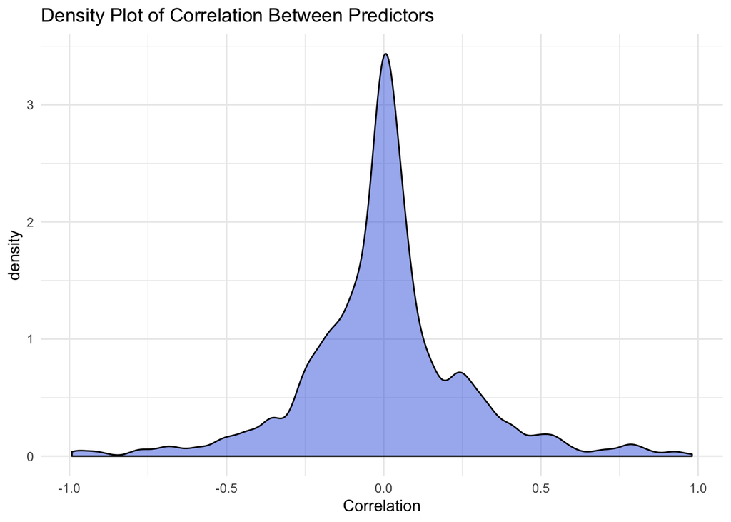

```r
# how closely correlated are the predictors with each other?
cor(train[,1:52]) %>% melt(.) %>% filter(Var1!=Var2) %>% arrange(desc(value)) %>%
  ggplot() +
  geom_density(aes(value), fill="royalblue", alpha=.5, color="black") +
  theme_minimal() +
  xlab("Correlation") +
  ggtitle("Density Plot of Correlation Between Predictors")
```

```r
# looks like some variables are highly correlated
# we can reduce the number of predictors with PCA
preProcValues <- preProcess(train, method = c("center", "scale","pca"))
traint <- predict(preProcValues, train)
testt <- predict(preProcValues, test)
```

## Data partitioning and model fitting

Here we partition the training data into a training set and a validation set. (We leave the test set for prediction later.)

```r
# now partition into a training and validation set
set.seed(007)
inTrain <- createDataPartition(traint$classe, p = 0.7, list = FALSE)
traint <- train[inTrain, ]
validt <- train[-inTrain, ]
```

We then fit three different ML models: (1) a random forest model, (2) a gradient boosting machine model, and (3) a linear discriminant analysis model. We will then review the results of each, focusing on the accuracy metric.

Let’s review the results of each model:

```r
mod.rf
```

```
## Random Forest
##
## 13737 samples
##    52 predictor
##     5 classes: 'A', 'B', 'C', 'D', 'E'
##
## No pre-processing
## Resampling: Cross-Validated (10 fold)
## Summary of sample sizes: 12364, 12363, 12362, 12365, 12364, 12363, ...
## Resampling results across tuning parameters:
##
##   mtry  Accuracy   Kappa
##    2    0.9919927  0.9898707
##   27    0.9917741  0.9895945
##   52    0.9864609  0.9828727
##
## Accuracy was used to select the optimal model using the largest value.
## The final value used for the model was mtry = 2.
```

```r
mod.gbm
```

```
## Stochastic Gradient Boosting
##
## 13737 samples
##    52 predictor
##     5 classes: 'A', 'B', 'C', 'D', 'E'
##
## No pre-processing
## Resampling: Bootstrapped (25 reps)
## Summary of sample sizes: 13737, 13737, 13737, 13737, 13737, 13737, ...
## Resampling results across tuning parameters:
##
##   interaction.depth  n.trees  Accuracy   Kappa
##   1                   50      0.7519742  0.6854888
##   1                  100      0.8163633  0.7673878
##   1                  150      0.8497166  0.8096702
##   2                   50      0.8517571  0.8120578
##   2                  100      0.9042015  0.8786798
##   2                  150      0.9294104  0.9106188
##   3                   50      0.8947973  0.8667365
##   3                  100      0.9392397  0.9230605
##   3                  150      0.9575220  0.9462239
##
## Tuning parameter 'shrinkage' was held constant at a value of 0.1
##
## Tuning parameter 'n.minobsinnode' was held constant at a value of 10
## Accuracy was used to select the optimal model using the largest value.
## The final values used for the model were n.trees = 150, interaction.depth =
##  3, shrinkage = 0.1 and n.minobsinnode = 10.
```

```r
mod.lda
```

```
## Linear Discriminant Analysis
##
## 13737 samples
##    52 predictor
##     5 classes: 'A', 'B', 'C', 'D', 'E'
##
## No pre-processing
## Resampling: Bootstrapped (25 reps)
## Summary of sample sizes: 13737, 13737, 13737, 13737, 13737, 13737, ...
## Resampling results:
##
##   Accuracy   Kappa
##   0.7009549  0.6214977
```

Let’s compare results:

```r
# check results
confusionMatrix(predict(mod.rf, traint), as.factor(traint$classe))
```

```
## Confusion Matrix and Statistics
##
##           Reference
## Prediction    A    B    C    D    E
##          A 3906    0    0    0    0
##          B    0 2658    0    0    0
##          C    0    0 2396    0    0
##          D    0    0    0 2252    0
##          E    0    0    0    0 2525
##
## Overall Statistics
##
##                Accuracy : 1
##                  95% CI : (0.9997, 1)
##     No Information Rate : 0.2843
##     P-Value [Acc > NIR] : < 2.2e-16
##
##                   Kappa : 1
##
##  Mcnemar's Test P-Value : NA
##
## Statistics by Class:
##
##                      Class: A Class: B Class: C Class: D Class: E
## Sensitivity            1.0000   1.0000   1.0000   1.0000   1.0000
## Specificity            1.0000   1.0000   1.0000   1.0000   1.0000
## Pos Pred Value         1.0000   1.0000   1.0000   1.0000   1.0000
## Neg Pred Value         1.0000   1.0000   1.0000   1.0000   1.0000
## Prevalence             0.2843   0.1935   0.1744   0.1639   0.1838
## Detection Rate         0.2843   0.1935   0.1744   0.1639   0.1838
## Detection Prevalence   0.2843   0.1935   0.1744   0.1639   0.1838
## Balanced Accuracy      1.0000   1.0000   1.0000   1.0000   1.0000
```

```r
confusionMatrix(predict(mod.gbm, traint), as.factor(traint$classe))
```

```
## Confusion Matrix and Statistics
##
##           Reference
## Prediction    A    B    C    D    E
##          A 3864   49    0    2    3
##          B   29 2565   52    2   10
##          C   12   43 2315   59   12
##          D    1    1   25 2180   30
##          E    0    0    4    9 2470
##
## Overall Statistics
##
##                Accuracy : 0.975
##                  95% CI : (0.9723, 0.9776)
##     No Information Rate : 0.2843
##     P-Value [Acc > NIR] : < 2.2e-16
##
##                   Kappa : 0.9684
##
##  Mcnemar's Test P-Value : 2.651e-09
##
## Statistics by Class:
##
##                      Class: A Class: B Class: C Class: D Class: E
## Sensitivity            0.9892   0.9650   0.9662   0.9680   0.9782
## Specificity            0.9945   0.9916   0.9889   0.9950   0.9988
## Pos Pred Value         0.9862   0.9650   0.9484   0.9745   0.9948
## Neg Pred Value         0.9957   0.9916   0.9928   0.9937   0.9951
## Prevalence             0.2843   0.1935   0.1744   0.1639   0.1838
## Detection Rate         0.2813   0.1867   0.1685   0.1587   0.1798
## Detection Prevalence   0.2852   0.1935   0.1777   0.1628   0.1808
## Balanced Accuracy      0.9919   0.9783   0.9775   0.9815   0.9885
```

```r
confusionMatrix(predict(mod.lda, traint), as.factor(traint$classe))
```

```
## Confusion Matrix and Statistics
##
##           Reference
## Prediction    A    B    C    D    E
##          A 3210  412  243  141   94
##          B   69 1709  235   96  435
##          C  320  330 1572  267  224
##          D  295   96  292 1657  234
##          E   12  111   54   91 1538
##
## Overall Statistics
##
##                Accuracy : 0.7051
##                  95% CI : (0.6974, 0.7127)
##     No Information Rate : 0.2843
##     P-Value [Acc > NIR] : < 2.2e-16
##
##                   Kappa : 0.6267
##
##  Mcnemar's Test P-Value : < 2.2e-16
##
## Statistics by Class:
##
##                      Class: A Class: B Class: C Class: D Class: E
## Sensitivity            0.8218   0.6430   0.6561   0.7358   0.6091
## Specificity            0.9095   0.9246   0.8994   0.9202   0.9761
## Pos Pred Value         0.7829   0.6718   0.5794   0.6437   0.8516
## Neg Pred Value         0.9278   0.9152   0.9253   0.9467   0.9173
## Prevalence             0.2843   0.1935   0.1744   0.1639   0.1838
## Detection Rate         0.2337   0.1244   0.1144   0.1206   0.1120
## Detection Prevalence   0.2985   0.1852   0.1975   0.1874   0.1315
## Balanced Accuracy      0.8656   0.7838   0.7777   0.8280   0.7926
```

```r
# the random forest has by far the highest accuracy
```

[output not shown]

## Prediction

Finally, let’s apply once to the test set to get our final results:

```
##  [1] B A B A A E D B A A B C B A E E A B B B
## Levels: A B C D E
```